# BellabeatDoc

Tejaswi

2022-12-25

## Introduction

Welcome to the Bellabeat data analysis case study!The Bellabeat app provides users with health data related to their activity, sleep, stress,menstrual cycle, and mindfulness habits.The Bellabeat app connects to their line of smart wellness Products.

## Scenario

I am a junior data analyst working on the marketing analyst team at Bellabeat, a high-tech manufacturer of health-focused products for women. Bellabeat is a successful small company, but they have the potential to become a larger player in the global smart device market. we have been asked to focus on one of Bellabeat’s products and analyze smart device data to gain insight into how consumers are using their smart devices. The insights we discover will then help guide marketing strategy for the company. we will present our analysis to the Bellabeat executive team along with our high-level recommendations for Bellabeat’s marketing strategy.

## key stakeholders

- Urška Sršen: Bellabeat’s cofounder and Chief Creative Officer
- Sando Mur: Mathematician and Bellabeat’s cofounder; key member of the Bellabeat executive team
- Bellabeat marketing analytics team: A team of data analysts responsible for collecting, analyzing, and reporting data that helps guide Bellabeat’s marketing strategy. I joined this team six months ago and have been busy learning about Bellabeat’’s mission and business goals — as well as how you, as a junior data analyst, can help Bellabeat achieve them.

## Business Task

To focus on one of Bellabeat’s products and analyze smart device data to gain insight into how consumers are using their smart devices. The insights you discover will then help guide marketing strategy for the company.

## preparing Data

#### Installing and loading Required packages

use install.packages() to install required packages for further analysis. loading the packages

```r
library(tidyverse)
library(readr)
library(lubridate)
```

```r
library(ggplot2)
library(ggpubr)
library(RColorBrewer)
library(scales)
library(waffle)
library(janitor)
```

#### collecting data

to know the working directory use getwd() and ti set the directory and further collect data setwd() after setting the directory, collect the required data sets.

```r
daily_activity <- read_csv("dailyActivity_merged.csv")
daily_sleep <- read_csv("sleepDay_merged.csv")
hourly_calories <- read_csv("hourlyCalories_merged.csv")
hourly_steps <- read_csv("hourlySteps_merged.csv")
weightLog_info <- read_csv("weightLogInfo_merged.csv")
```

#### a quick preview of data

we can also use View() function. to view the data set.

```r
head(daily_activity)
```

```
## # A tibble: 6 × 15
##       Id Activ…¹ Total…² Total…³ Track…⁴ Logge…⁵ VeryA…⁶ Moder…⁷ Light…⁸ Seden…⁹
##    <dbl> <chr>     <dbl>   <dbl>   <dbl>   <dbl>   <dbl>   <dbl>   <dbl>   <dbl>
## 1 1.50e9 4/12/2…   13162    8.5     8.5        0    1.88   0.550    6.06       0
## 2 1.50e9 4/13/2…   10735    6.97    6.97       0    1.57   0.690    4.71       0
## 3 1.50e9 4/14/2…   10460    6.74    6.74       0    2.44   0.400    3.91       0
## 4 1.50e9 4/15/2…    9762    6.28    6.28       0    2.14   1.26     2.83       0
## 5 1.50e9 4/16/2…   12669    8.16    8.16       0    2.71   0.410    5.04       0
## 6 1.50e9 4/17/2…    9705    6.48    6.48       0    3.19   0.780    2.51       0
## # … with 5 more variables: VeryActiveMinutes <dbl>, FairlyActiveMinutes <dbl>,
## #   LightlyActiveMinutes <dbl>, SedentaryMinutes <dbl>, Calories <dbl>, and
## #   abbreviated variable names ¹ActivityDate, ²TotalSteps, ³TotalDistance,
## #   ⁴TrackerDistance, ⁵LoggedActivitiesDistance, ⁶VeryActiveDistance,
## #   ⁷ModeratelyActiveDistance, ⁸LightActiveDistance, ⁹SedentaryActiveDistance
```

```r
str(daily_activity)
```

```
## spc_tbl_ [940 × 15] (S3: spec_tbl_df/tbl_df/tbl/data.frame)
##  $ Id                      : num [1:940] 1.5e+09 1.5e+09 1.5e+09 1.5e+09 1.5e+09 ...
##  $ ActivityDate            : chr [1:940] "4/12/2016" "4/13/2016" "4/14/2016" "4/15/2016" ...
##  $ TotalSteps              : num [1:940] 13162 10735 10460 9762 12669 ...
##  $ TotalDistance           : num [1:940] 8.5 6.97 6.74 6.28 8.16 ...
##  $ TrackerDistance         : num [1:940] 8.5 6.97 6.74 6.28 8.16 ...
##  $ LoggedActivitiesDistance: num [1:940] 0 0 0 0 0 0 0 0 0 0 ...
##  $ VeryActiveDistance      : num [1:940] 1.88 1.57 2.44 2.14 2.71 ...
##  $ ModeratelyActiveDistance: num [1:940] 0.55 0.69 0.4 1.26 0.41 ...
##  $ LightActiveDistance     : num [1:940] 6.06 4.71 3.91 2.83 5.04 ...
##  $ SedentaryActiveDistance : num [1:940] 0 0 0 0 0 0 0 0 0 0 ...
##  $ VeryActiveMinutes       : num [1:940] 25 21 30 29 36 38 42 50 28 19 ...
##  $ FairlyActiveMinutes     : num [1:940] 13 19 11 34 10 20 16 31 12 8 ...
##  $ LightlyActiveMinutes    : num [1:940] 328 217 181 209 221 164 233 264 205 211 ...
##  $ SedentaryMinutes        : num [1:940] 728 776 1218 726 773 ...
##  $ Calories                : num [1:940] 1985 1797 1776 1745 1863 ...
##  - attr(*, "spec")=
##   .. cols(
##   ..   Id = col_double(),
##   ..   ActivityDate = col_character(),
##   ..   TotalSteps = col_double(),
##   ..   TotalDistance = col_double(),
##   ..   TrackerDistance = col_double(),
##   ..   LoggedActivitiesDistance = col_double(),
##   ..   VeryActiveDistance = col_double(),
##   ..   ModeratelyActiveDistance = col_double(),
##   ..   LightActiveDistance = col_double(),
##   ..   SedentaryActiveDistance = col_double(),
##   ..   VeryActiveMinutes = col_double(),
##   ..   FairlyActiveMinutes = col_double(),
##   ..   LightlyActiveMinutes = col_double(),
##   ..   SedentaryMinutes = col_double(),
##   ..   Calories = col_double()
##   .. )
##  - attr(*, "problems")=<externalptr>
```

```r
head(daily_sleep)
```

```
## # A tibble: 6 × 5
##           Id SleepDay              TotalSleepRecords TotalMinutesAsleep TotalT…¹
##        <dbl> <chr>                             <dbl>              <dbl>    <dbl>
## 1 1503960366 4/12/2016 12:00:00 AM                 1                327      346
## 2 1503960366 4/13/2016 12:00:00 AM                 2                384      407
## 3 1503960366 4/15/2016 12:00:00 AM                 1                412      442
## 4 1503960366 4/16/2016 12:00:00 AM                 2                340      367
## 5 1503960366 4/17/2016 12:00:00 AM                 1                700      712
## 6 1503960366 4/19/2016 12:00:00 AM                 1                304      320
## # … with abbreviated variable name ¹TotalTimeInBed
```

```r
str(daily_sleep)
```

```
## spc_tbl_ [413 × 5] (S3: spec_tbl_df/tbl_df/tbl/data.frame)
##  $ Id                : num [1:413] 1.5e+09 1.5e+09 1.5e+09 1.5e+09 1.5e+09 ...
##  $ SleepDay          : chr [1:413] "4/12/2016 12:00:00 AM" "4/13/2016 12:00:00 AM" "4/15/2016 12:00:00 AM" "4/16/2016 12:00:00 AM" ...
##  $ TotalSleepRecords : num [1:413] 1 2 1 2 1 1 1 1 1 1 ...
##  $ TotalMinutesAsleep: num [1:413] 327 384 412 340 700 304 360 325 361 430 ...
##  $ TotalTimeInBed    : num [1:413] 346 407 442 367 712 320 377 364 384 449 ...
##  - attr(*, "spec")=
##   .. cols(
##   ..   Id = col_double(),
##   ..   SleepDay = col_character(),
##   ..   TotalSleepRecords = col_double(),
##   ..   TotalMinutesAsleep = col_double(),
##   ..   TotalTimeInBed = col_double()
##   .. )
##  - attr(*, "problems")=<externalptr>
```

#### verifying data

to verify the data, we check the number of users, check if there are any duplicates in the data, check if there are any null values in data.

```r
n_distinct(daily_activity$Id)
```

```
## [1] 33
```

```r
n_distinct(daily_sleep$Id)
```

```
## [1] 24
```

verify if there are any null values in the dataset

```r
sum(is.null(daily_activity))
```

```
## [1] 0
```

```r
sum(is.null(daily_sleep))
```

```
## [1] 0
```

verify if there are any duplicate values in the dataset

```r
sum(duplicated(daily_activity))
```

```
## [1] 0
```

```r
sum(duplicated(daily_sleep))
```

```
## [1] 3
```

As we can see that there are three duplicate values in daily_sleep dataset. we need to handle and make sure that there are no duplicates in dataset

```r
daily_sleep <- unique(daily_sleep)
sum(duplicated(daily_sleep))
```

```
## [1] 0
```

#### cleaning data

using clean_names() function to make sure that all column names or fields are in proper format and consistent.

```r
daily_activity <- daily_activity %>%
  clean_names()
daily_sleep <- daily_sleep %>%
  clean_names()
hourly_calories <- hourly_calories %>%
  clean_names()
hourly_steps <- hourly_steps %>%
  clean_names()
weightLog_info <- weightLog_info %>%
  clean_names()
```

checking the activity date format in both daily_activity and daily_sleep dataset, we can see that data type of activity_date is character, it needs to be converted into date format, and also rename the sleep_day column in daily_sleep dataset to activity_date.

```r
daily_activity <- mutate(daily_activity, activity_date = as.Date(activity_date, "%m/%d/%Y"))
head(daily_activity) #check the data type of activity_date now
```

```
## # A tibble: 6 × 15
##           id activity_…¹ total…² total…³ track…⁴ logge…⁵ very_…⁶ moder…⁷ light…⁸
##        <dbl> <date>        <dbl>   <dbl>   <dbl>   <dbl>   <dbl>   <dbl>   <dbl>
## 1 1503960366 2016-04-12    13162    8.5     8.5        0    1.88   0.550    6.06
## 2 1503960366 2016-04-13    10735    6.97    6.97       0    1.57   0.690    4.71
## 3 1503960366 2016-04-14    10460    6.74    6.74       0    2.44   0.400    3.91
## 4 1503960366 2016-04-15     9762    6.28    6.28       0    2.14   1.26     2.83
## 5 1503960366 2016-04-16    12669    8.16    8.16       0    2.71   0.410    5.04
## 6 1503960366 2016-04-17     9705    6.48    6.48       0    3.19   0.780    2.51
## # … with 6 more variables: sedentary_active_distance <dbl>,
## #   very_active_minutes <dbl>, fairly_active_minutes <dbl>,
## #   lightly_active_minutes <dbl>, sedentary_minutes <dbl>, calories <dbl>, and
## #   abbreviated variable names ¹activity_date, ²total_steps, ³total_distance,
## #   ⁴tracker_distance, ⁵logged_activities_distance, ⁶very_active_distance,
## #   ⁷moderately_active_distance, ⁸light_active_distance
```

```r
daily_sleep <- mutate(daily_sleep, sleep_day = as.Date(sleep_day, "%m/%d/%Y %I:%M:%S %p")) %>%
  rename(activity_date = sleep_day)
```

adding a day of week column to daily_activity data set to get the insights of steps,calories, through out a week.

```r
daily_activity$day_of_week <- format(as.Date(daily_activity$activity_date),"%A")
```

using summary function to get some more insights on total_steps in daily_activity dataset.to know the minimum, maximum and average steps

```r
summary(daily_activity$total_steps)
```

```
##    Min. 1st Qu.  Median    Mean 3rd Qu.    Max.
##       0    3790    7406    7638   10727   36019
```

```r
filter(daily_activity,total_steps == 0) # as from above summary we see minimum steps as zero
```

```
## # A tibble: 77 × 16
##            id activity…¹ total…² total…³ track…⁴ logge…⁵ very_…⁶ moder…⁷ light…⁸
##         <dbl> <date>       <dbl>   <dbl>   <dbl>   <dbl>   <dbl>   <dbl>   <dbl>
##  1 1503960366 2016-05-12       0       0       0       0       0       0       0
##  2 1844505072 2016-04-24       0       0       0       0       0       0       0
##  3 1844505072 2016-04-25       0       0       0       0       0       0       0
##  4 1844505072 2016-04-26       0       0       0       0       0       0       0
##  5 1844505072 2016-05-02       0       0       0       0       0       0       0
##  6 1844505072 2016-05-07       0       0       0       0       0       0       0
##  7 1844505072 2016-05-08       0       0       0       0       0       0       0
##  8 1844505072 2016-05-09       0       0       0       0       0       0       0
##  9 1844505072 2016-05-10       0       0       0       0       0       0       0
## 10 1844505072 2016-05-11       0       0       0       0       0       0       0
## # … with 67 more rows, 7 more variables: sedentary_active_distance <dbl>,
## #   very_active_minutes <dbl>, fairly_active_minutes <dbl>,
## #   lightly_active_minutes <dbl>, sedentary_minutes <dbl>, calories <dbl>,
## #   day_of_week <chr>, and abbreviated variable names ¹activity_date,
## #   ²total_steps, ³total_distance, ⁴tracker_distance,
## #   ⁵logged_activities_distance, ⁶very_active_distance,
## #   ⁷moderately_active_distance, ⁸light_active_distance
```

```r
daily_activity <- daily_activity[daily_activity$total_steps > 0,]
summary(daily_activity$total_steps)
```

```
##    Min. 1st Qu.  Median    Mean 3rd Qu.    Max.
##       4    4923    8053    8319   11092   36019
```

performing inner join on daily_activity and daily_sleep by using id and activity_date columns as they are common in both datasets.

```r
daily_sleep <- inner_join(daily_activity, daily_sleep, c("id","activity_date"))
head(daily_sleep)
```

```
## # A tibble: 6 × 19
##           id activity_…¹ total…² total…³ track…⁴ logge…⁵ very_…⁶ moder…⁷ light…⁸
##        <dbl> <date>        <dbl>   <dbl>   <dbl>   <dbl>   <dbl>   <dbl>   <dbl>
## 1 1503960366 2016-04-12    13162    8.5     8.5        0    1.88   0.550    6.06
## 2 1503960366 2016-04-13    10735    6.97    6.97       0    1.57   0.690    4.71
## 3 1503960366 2016-04-15     9762    6.28    6.28       0    2.14   1.26     2.83
## 4 1503960366 2016-04-16    12669    8.16    8.16       0    2.71   0.410    5.04
## 5 1503960366 2016-04-17     9705    6.48    6.48       0    3.19   0.780    2.51
## 6 1503960366 2016-04-19    15506    9.88    9.88       0    3.53   1.32     5.03
## # … with 10 more variables: sedentary_active_distance <dbl>,
## #   very_active_minutes <dbl>, fairly_active_minutes <dbl>,
## #   lightly_active_minutes <dbl>, sedentary_minutes <dbl>, calories <dbl>,
## #   day_of_week <chr>, total_sleep_records <dbl>, total_minutes_asleep <dbl>,
## #   total_time_in_bed <dbl>, and abbreviated variable names ¹activity_date,
## #   ²total_steps, ³total_distance, ⁴tracker_distance,
## #   ⁵logged_activities_distance, ⁶very_active_distance, …
```

try to get some insights on the total time slept and total time spent on bed.use summary to get min, max and average of time sent on sleep

```r
daily_sleep %>%
  select(total_minutes_asleep, total_time_in_bed) %>%
  drop_na() %>%
  summary()
```

```
##  total_minutes_asleep total_time_in_bed
##  Min.   : 58.0        Min.   : 61.0
##  1st Qu.:361.0        1st Qu.:403.8
##  Median :432.5        Median :463.0
##  Mean   :419.2        Mean   :458.5
##  3rd Qu.:490.0        3rd Qu.:526.0
##  Max.   :796.0        Max.   :961.0
```

using summary function to get insights on calories,setps,and active minutes from daily_activity dataset

```r
daily_activity %>%
  select(total_steps, very_active_minutes, fairly_active_minutes, lightly_active_minutes, sedentary_minutes, calories) %>%
  drop_na() %>%
  summary()
```

```
##   total_steps    very_active_minutes fairly_active_minutes
##  Min.   :    4   Min.   :  0.00      Min.   :  0.00
##  1st Qu.: 4923   1st Qu.:  0.00      1st Qu.:  0.00
##  Median : 8053   Median :  7.00      Median :  8.00
##  Mean   : 8319   Mean   : 23.02      Mean   : 14.78
##  3rd Qu.:11092   3rd Qu.: 35.00      3rd Qu.: 21.00
##  Max.   :36019   Max.   :210.00      Max.   :143.00
##  lightly_active_minutes sedentary_minutes    calories
##  Min.   :  0.0          Min.   :   0.0    Min.   :  52
##  1st Qu.:146.5          1st Qu.: 721.5    1st Qu.:1856
##  Median :208.0          Median :1021.0    Median :2220
##  Mean   :210.0          Mean   : 955.8    Mean   :2361
##  3rd Qu.:272.0          3rd Qu.:1189.0    3rd Qu.:2832
##  Max.   :518.0          Max.   :1440.0    Max.   :4900
```

ordering the day_of_week column in daily_sleep and daily_activity column as the order of days is supposed to be ‘sunday’,‘monday’,‘tuesday,’wednesday’,‘thursday’,‘friday’,‘saturday’.

```r
daily_sleep$day_of_week <- ordered(daily_sleep$day_of_week, levels = c('Sunday','Monday','Tuesday','Wednesday','Thursday','Friday','Saturday'))
daily_activity$day_of_week <- ordered(daily_activity$day_of_week, levels = c('Sunday','Monday','Tuesday','Wednesday','Thursday','Friday','Saturday'))
```

visualizing the minutes of sleep on average on each weekday

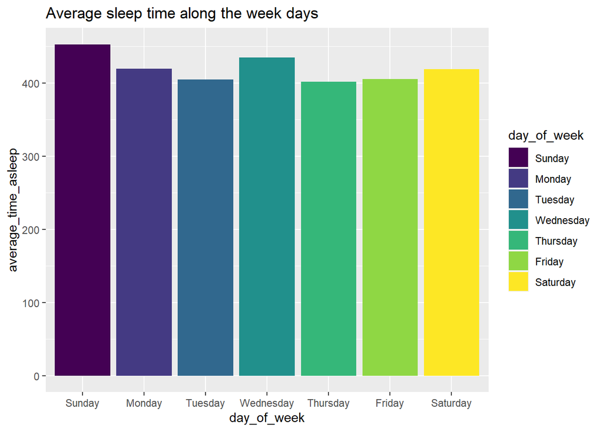

```r
daily_sleep %>%
  group_by(day_of_week) %>%
  summarise(average_time_asleep = mean(total_minutes_asleep), average_time_in_bed = mean(total_time_in_bed)) %>%
  arrange(day_of_week) %>%
  ggplot(aes(x=day_of_week, y=average_time_asleep, fill=day_of_week)) + geom_col(position = 'dodge') + labs(title="Average sleep time along the week days")
```

- from the above visualization we can say that average time of sleep in more on sunday and wednesday and looks like the average minutes asleep does not differ much along the week. asleep minutes does not seem to be affected by any activities on weekdays.

visualizing on total_minutes_asleep and total_time_in_bed

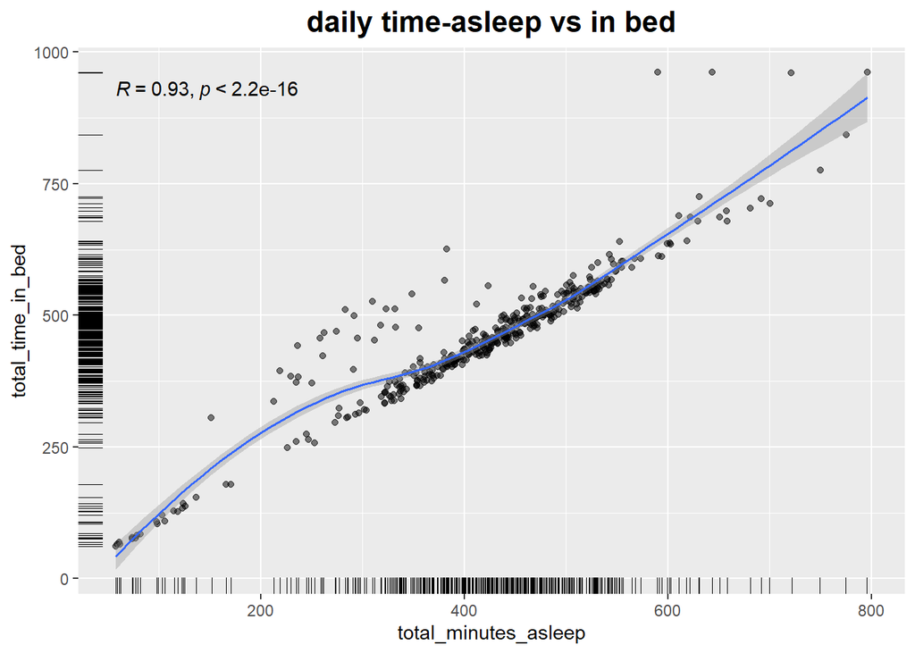

```r
daily_sleep %>%
  ggplot(aes(x=total_minutes_asleep,y=total_time_in_bed)) +
  geom_jitter(alpha=.5) +
  geom_rug(position="jitter",size = .08) +
  geom_smooth(size=.6) +
  stat_cor(method="pearson") +
  theme(plot.title = element_text(hjust = 0.5, size = 16, face="bold")) +
  labs(title="daily time-asleep vs in bed")
```

from the above visualization we would know that -

- total_minutes_asleep is correlated with total_time_in_bed, with correlation coefficient as 0.93

Visualizing on total_steps and calories

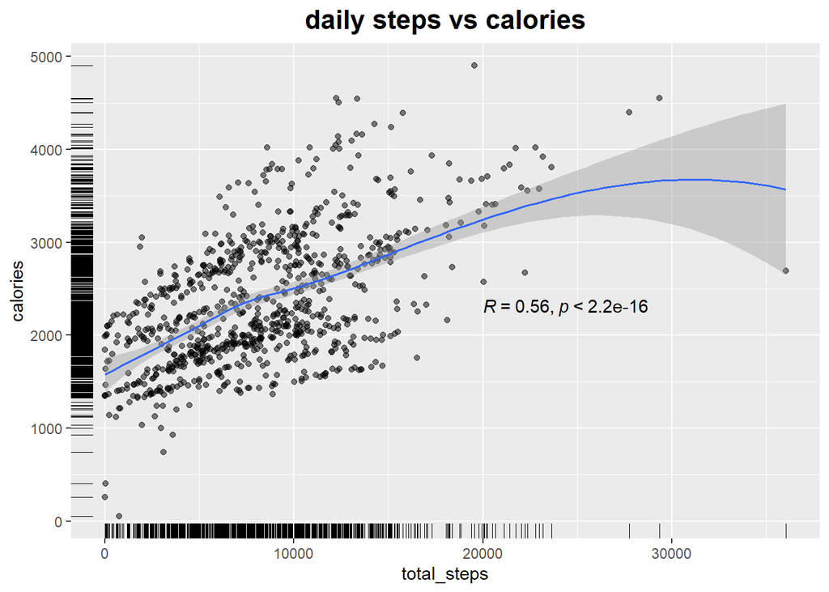

```r
daily_activity %>%
  ggplot(aes(x=total_steps,y=calories)) +
  geom_jitter(alpha=.5) +
  geom_rug(position="jitter", size = .08) +
  geom_smooth(size = .6) +
  stat_cor(method="pearson", label.x = 20000, label.y = 2300) +
  theme(plot.title = element_text(hjust = 0.5, size = 16, face="bold")) +
  labs(title="daily steps vs calories")
```

visualizing on total_steps and total_minutes_asleep

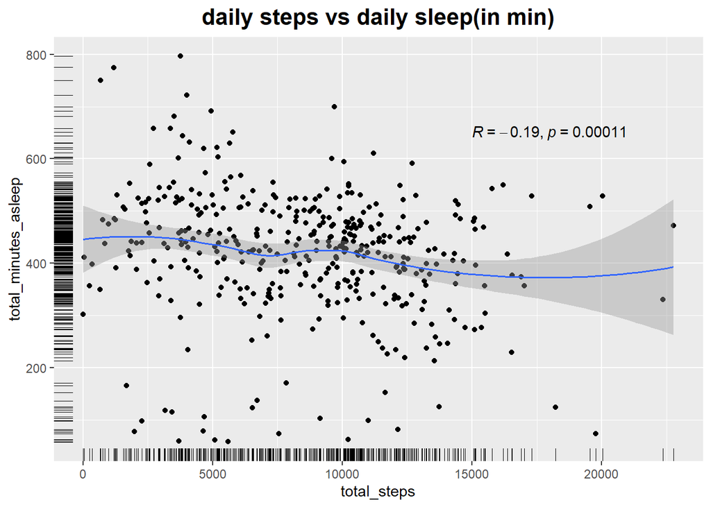

```r
daily_sleep %>%
  ggplot(aes(x=total_steps, y=total_minutes_asleep)) +
  geom_jitter(apha=.5) +
  geom_rug(position = "jitter", size = .08) +
  geom_smooth(size = .6) +
  stat_cor(method="pearson", label.x = 15000, label.y = 650) +
  theme(plot.title = element_text(hjust = 0.5, size = 16, face = "bold")) +
  labs(title="daily steps vs daily sleep(in min)")
```

#### Categorizing users based on their daily steps

from this [article](https://www.10000steps.org.au/articles/healthy-lifestyles/counting-steps/) I have got some measures to categorize user’s based on their daily steps

- Sedentary is less than 5,000 steps per day(<5000)
- Low active is 5,000 to 7,499 steps per day(>5000 and <7500)
- Fairly active is 7,500 to 9,999 steps per day(>7500 and <10000)
- Active is more than 10,000 steps per day

```r
type_of_user_by_steps <- daily_activity %>%
  select(id, total_steps, calories) %>%
  group_by(id) %>%
  summarise(daily_average_steps = mean(total_steps), daily_average_calories = mean(calories)) %>%
  mutate(user_type = case_when(
    daily_average_steps < 5000 ~ "Sedentary",
    daily_average_steps >= 5000 & daily_average_steps < 7500 ~ "Lightly Active",
    daily_average_steps >= 7500 & daily_average_steps < 10000 ~ "Fairly Active",
    daily_average_steps >=10000 ~ "Very Active"
  ))

head(type_of_user_by_steps)
```

```
## # A tibble: 6 × 4
##           id daily_average_steps daily_average_calories user_type
##        <dbl>               <dbl>                  <dbl> <chr>
## 1 1503960366              12521.                  1877. Very Active
## 2 1624580081               5744.                  1483. Lightly Active
## 3 1644430081               7283.                  2811. Lightly Active
## 4 1844505072               3809.                  1714. Sedentary
## 5 1927972279               1671.                  2303. Sedentary
## 6 2022484408              11371.                  2510. Very Active
```

to calculate percentage of each type of users so we can create user_type_percentage

```r
user_type_percentage <- type_of_user_by_steps %>%
  group_by(user_type) %>%
  summarise(total = n()) %>%
  mutate(totals = sum(total)) %>%
  group_by(user_type) %>%
  summarise(total_percentage = total/totals) %>%
  mutate(labels = scales::percent(total_percentage))

user_type_percentage$user_type <- factor(user_type_percentage$user_type, levels=c("Very Active","Fairly Active","Lightly Active","Sedentary"))

head(user_type_percentage)
```

```
## # A tibble: 4 × 3
##   user_type      total_percentage labels
##   <fct>                     <dbl> <chr>
## 1 Fairly Active             0.303 30.3%
## 2 Lightly Active            0.273 27.3%
## 3 Sedentary                 0.212 21.2%
## 4 Very Active               0.212 21.2%
```

visualizing with pie chart on user types categorized by total_steps

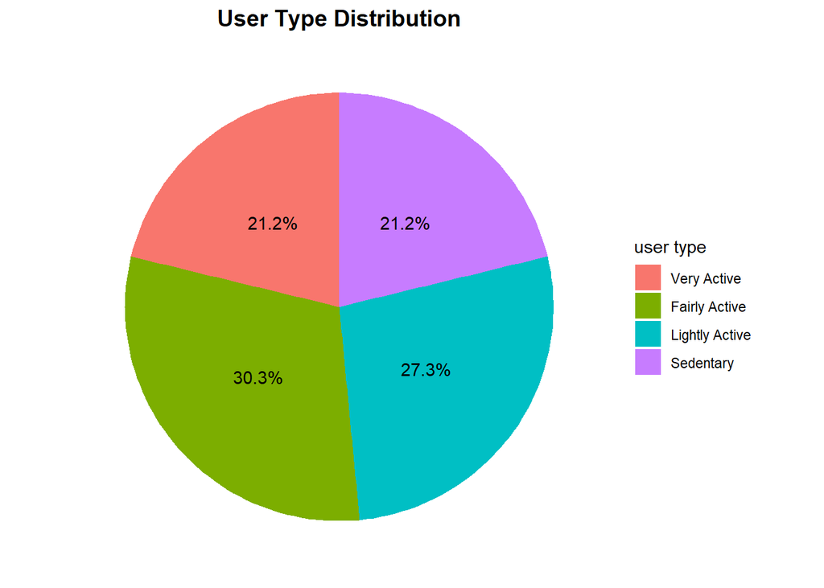

```r
user_type_percentage %>%
  ggplot(aes(x="",y=total_percentage,fill=user_type)) +
  geom_bar(stat = "identity", width = 1) +
  coord_polar("y", start = 0) +
  theme_minimal() +
  theme(axis.title.x = element_blank(),
        axis.title.y = element_blank(),
        panel.border = element_blank(),
        panel.grid = element_blank(),
        axis.ticks = element_blank(),
        axis.text.x = element_blank(),
        plot.title = element_text(hjust = 0.5, size = 14, face = "bold")) +
  geom_text(aes(label = labels),
            position = position_stack(vjust=0.5)) +
  guides(fill = guide_legend(title = "user type")) +
  labs(title = "User Type Distribution")
```

#### Hourly steps through out the week days

going though the hourly steps and group by activity date and time and add day_of_week column

```r
hourly_steps <- hourly_steps %>%
  separate(activity_hour,into = c("activity_date","activity_time"), sep=" ")
hourly_steps <- mutate(hourly_steps, activity_date = as.Date(activity_date, "%m/%d/%Y"))
hourly_steps$day_of_week <- format(as.Date(hourly_steps$activity_date), "%A")
head(hourly_steps)
```

```
## # A tibble: 6 × 5
##           id activity_date activity_time step_total day_of_week
##        <dbl> <date>        <chr>              <dbl> <chr>
## 1 1503960366 2016-04-12    12:00:00             373 Tuesday
## 2 1503960366 2016-04-12    1:00:00              160 Tuesday
## 3 1503960366 2016-04-12    2:00:00              151 Tuesday
## 4 1503960366 2016-04-12    3:00:00                0 Tuesday
## 5 1503960366 2016-04-12    4:00:00                0 Tuesday
## 6 1503960366 2016-04-12    5:00:00                0 Tuesday
```

create steps_on_weekday to get aggregated total steps on each weekday and activity_time

```r
steps_on_weekday <- hourly_steps %>%
  select(day_of_week, activity_time, step_total) %>%
  group_by(day_of_week, activity_time) %>%
  summarize(average_steps=round(mean(step_total)))
steps_on_weekday$day_of_week <- ordered(steps_on_weekday$day_of_week, levels = c("Sunday","Monday","Tuesday","Wednesday","Thursday","Friday","Saturday"))
```

Visualizing steps_on_week on a heatmap

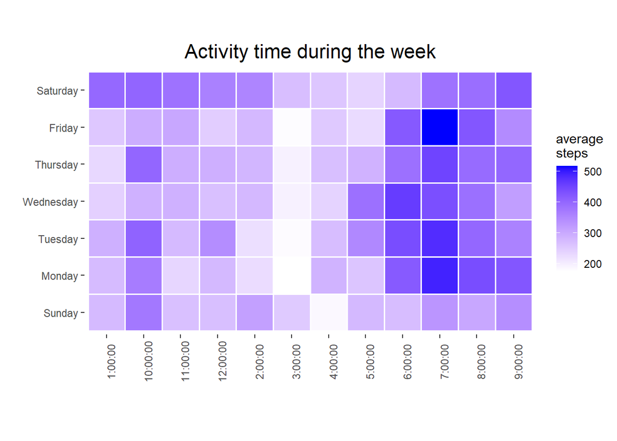

```r
steps_on_weekday %>%
  ggplot(aes(x=activity_time, y=day_of_week, fill=average_steps)) +
  theme(axis.text.x=element_text(angle=90)) +
  labs(title="Activity time during the week", x=" ", y=" ", fill="average\nsteps") +
  scale_fill_gradient(low = "white", high="blue") +
  geom_tile(color="white",lwd=.6,linetype=1) +
  coord_fixed() +
  theme(plot.title=element_text(hjust=0.5, vjust=0.8, size=16), panel.background=element_blank())
```

## Act - Recommendation

In order to respond to the business task and help bellabeat, I would suggest to use our own tracking data for any further analysis and as the data was limited to few months, the findings could not be accurate. and if we want to focus on certain age group of people then it would be helpful if we have more specific data to further observe the trends and drive some insights from it.

below are the findings, from analysis: * from the above summary of total_steps we can see that average steps are 8319, but it is said that 10,000 steps per day would be good for an healthy adult.